# Example Markdown File

JJB + Course

6/14/2016

# Introduction to Markdown

Hello Class.

How are you?

Class Response: *Good.*

Are you sure?

Class Response: **Yeah.**

What are your favorite kinds of Ice Cream?

- Coffee Ice Cream
- Mint Chocolate Chip
- [Black Raspberry Chocolate Chip](http://www.graeters.com/black-raspberry-chocolate-chip)

What does *Black Raspberry Chocolate Chip* look like?

[figure not shown]

What it looks like

Most important things to learn in **College**:

1. Sleep Well.
2. Time Management
3. [Coffee!](http://members.starbucks.com/)
4. Extracurriculars in [different fields](http://mrdc.ec.illinois.edu/)

Best place to eat is:

1. Cravings
2. Maize
3. Black Dog
   1. Pork Ribs
   2. Burnt Ends
   3. Cuban Sandwich
      - Make sure to avoid putting one in the microwave if it has tinfoil around it…
4. McDonald…

# Let’s Do Some R

In this case, we want to investigate the volume of discharge of the Nile river in Egypt.

To do so, we should probably:

1. Load the data
2. Run a quick analysis

The amount of observations is: 100. I obtained this using the `length()` function.

What does our data look like?

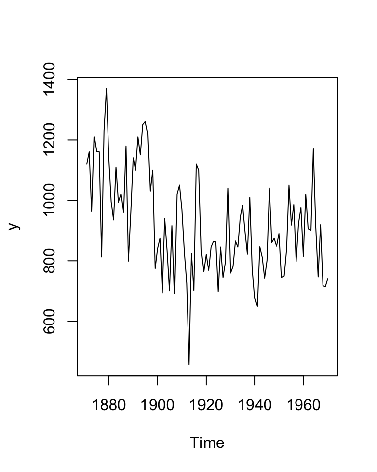

```r
plot(y)              # Plot the data
```

What would happen if we tried to model the data using time as our explanatory variable?

```r
x = (1:obs)          # Create a time index
model = lm(y ~ x)    # Perform a simple linear regression (SLR)

model                # View model estimates
```

```
##
## Call:
## lm(formula = y ~ x)
##
## Coefficients:
## (Intercept)            x
##    1056.422       -2.714
```

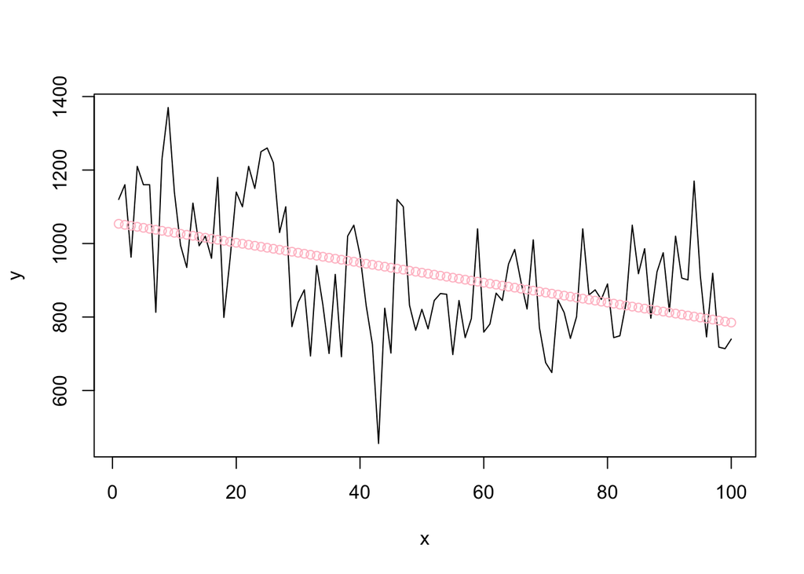

```r
plot(x, y, type='l') # Plot the model (note time index)
points(fitted(model), col='pink') # Plot the fitted values from the model
```

Let’s take a look at how well the model performs by running some inference upon it:

```r
summary(model)       # View model summary
```

```
##
## Call:
## lm(formula = y ~ x)
##
## Residuals:
##     Min      1Q  Median      3Q     Max
## -483.71  -98.17  -23.21  111.40  368.72
##
## Coefficients:
##              Estimate Std. Error t value Pr(>|t|)
## (Intercept) 1056.4224    30.3377  34.822  < 2e-16 ***
## x             -2.7143     0.5216  -5.204 1.07e-06 ***
## ---
## Signif. codes:  0 '***' 0.001 '**' 0.01 '*' 0.05 '.' 0.1 ' ' 1
##
## Residual standard error: 150.6 on 98 degrees of freedom
## Multiple R-squared:  0.2165, Adjusted R-squared:  0.2085
## F-statistic: 27.08 on 1 and 98 DF,  p-value: 1.072e-06
```